# Toys on Amazon Case Study

Story-telling with data

Ying Suo

2019-10-21

# Business Question

There are thousands of toy products selling on Amazon, and we would like to gain insights on the top popular products and how to improve sales. Popularity of a product could be effected by multiple factors such as the product manufacturers, price, rating, category and customer reviews, etc. To do this, we explored the toys on Amazon dataset on different factors, and created predictive model on Amazon Best Seller Rank, which indicates the product popularity and would also improve the future sales since Amazon has certain promotion activities towards high rank products. The analysis below will expound upon my findings.

# Agenda

- Data Management Approach
- Data Preperation
- Exploration and Visualization
- Modeling
- Summary and Wayforward
- Appendix
  - Appendix A. Metadata
  - Appendix B. Sample Codes
  - Appendix C. Improvements

## Data Management Approach

- Used **tidyr, stringr, lubridate** to clean the data: separate(), mutate(), pipe function and regular expression for data separation, extraction and formatting

  See Appendix B for sample codes
- Used **tidyverse, dplyr** for data wrangling: group_by(), summarize(), filter(), arrange() for data transformation, filtering and ordering
- Used **ggplot2** to visualize the data: ggplot(), geom_point(), geom_bar(), geom_line() and combinations for different graphics
- Used **modelr** to create statistical models: lm() for linear model, par() and plot() for residual and statistics plots

## Data Preperation

The Toys on Amazon dataset contained 16 variables and 10,000 observations of toys information from Amazon. After viewing the data, I noticed that some of the variables in the dataset were not in good format which would effect the furture analysis. For example, lots of missing values, the data type of price and reivew rating were not numeric, multiple seller names and prices information in one cell, etc. Thus, I decided to first clean the data and format them into good shape.

The new data structure contains 7 tables: Amazon_products_cd(cleaned full data), Product, Category, Also_Bought, QandA, Reviews, and Sellers.

See Appendix A for metadata

In addition to cleaning the data and make sure that each cell only has one value, I also extracted the Best Seller Rank and date first available information from variable “product_information”. These are the important components to predict the Best Seller Rank.

## Exploration and Visualization

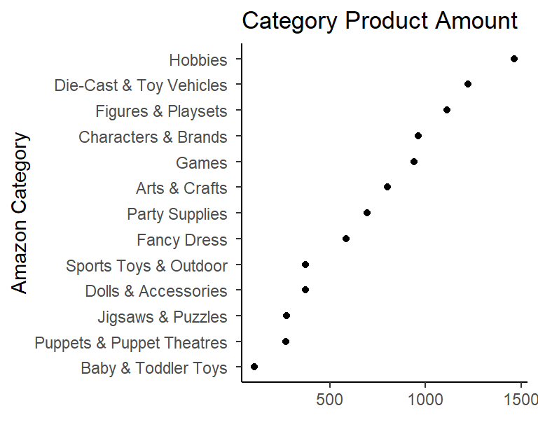

Looking at the first Amazon category level, Hobbies has the largest amount of products, followed by Die-Cast & Toy Vehicles and Figures & Playsets with more than 1000 products. While Games has the largest reviews amount, which indicates the best sales volume for this category.

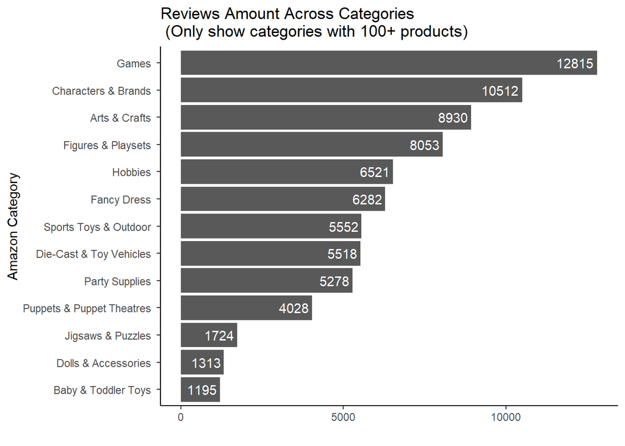

In terms of category average rating, it does not have significant difference between categories. The Doll & Accessories category has the best average rating of 4.81, while Sports Toys & Outdoor has the lowest average rating of 4.58.

Looking at product level, the overall product average rating is about 4.70, and average number of reviews is only 9. Consider certain amount of buyer base, set a) number of reviews above 100 and b) review rating above or equal to 4.7 as two criterias of popular products. There are total **41** popular products from this dataset. Here listed the most popular 10 products with number of reviews and their best seller rank. We can see that the top products are also the high ranking ones according to Amazon best seller rank. There are 4 out of 10 products come from Games category, which reflects that this category has the potential to generate more popular products.

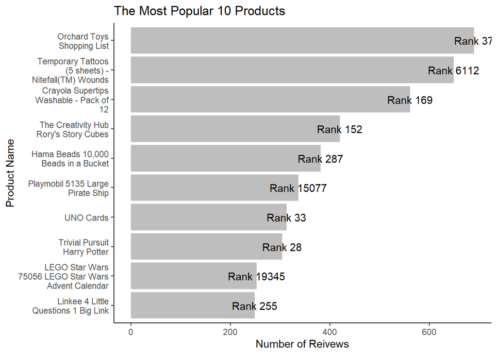

If take a closer look at the 41 top products’ manufacturer, brands like LEGO stand out. LEGO has 6 out 41 popular products. Besides LEGO, we can see other big name manufacturers like Palymobil and Star Wars also have multiple products on the list. This indicates that the famous brand name have great influence towards customers.

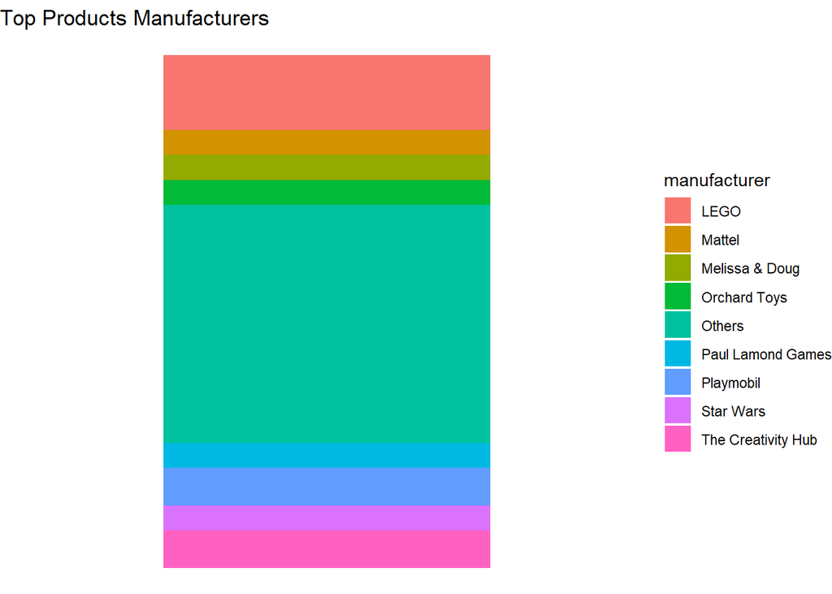

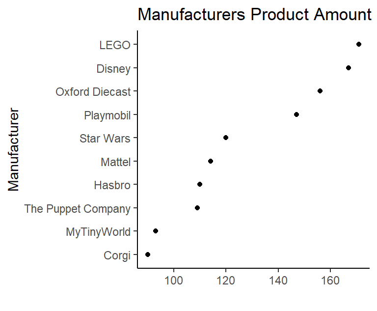

Going by the manufacturers. The biggest manufacturer LEGO has the most products of 171 toys, followed by Disney(167) and Oxford Diecast(156). Looking at the number of reviews of the products from each manufacturer, the big manufactures do have higher sales(reviews) given their product amount.

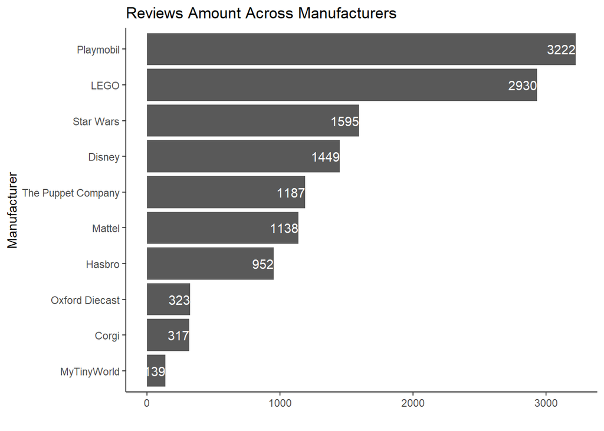

However, comparing to overall product review rating (4.70), LEGO’s average product rating is just above the average while Disney and Playmobil have not yet reach the average level. MyTinyWorld is ahead of the list with the average rating of 4.92. Sometimes not every product from the big name manufacturers could remain high quality and go popular among the market because of brand cannibalization or strategy mistakes. Meanwhile, the middle manufacturers produce less amount of toys but could have better reviews.

## Modeling

**Amazon Best Sellers Rank** is a number that each product has in their amazon category. For example, the Amazon Best Sellers Rank for Hornby 2014 Catalogue is #52,854. This means that out of the hundreds of thousands of products in Amazon’s Toys & Games department, this particular product is ranked 52,854th. The rank is based on couple of factors such as sales and price, and shows the popularity of the product. It would also improve the future sales since Amazon has certain promotion activities towards high rank products.

See more explanation for [Amazon Best Sellers Rank](https://www.junglescout.com/blog/amazon-best-sellers-rank/)

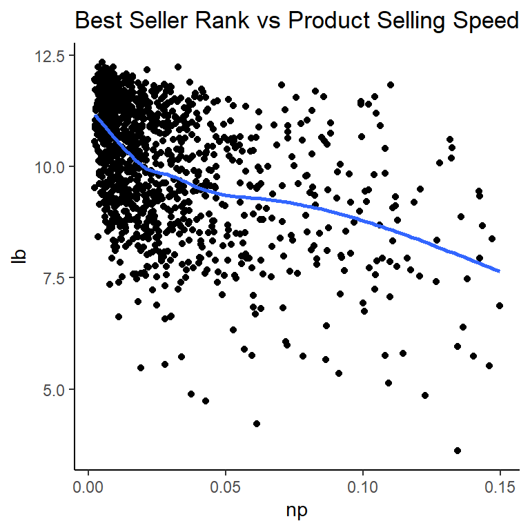

31% of the Best Seller Rank data could be explained by how fast the product is sold, how many sellers the product has and the price of the product.

Then I visualize the prediction of the Best Seller Rank using the above model. There are more blue points that are far away from the prediction line, indicating that the more actual values are much less than predicted.

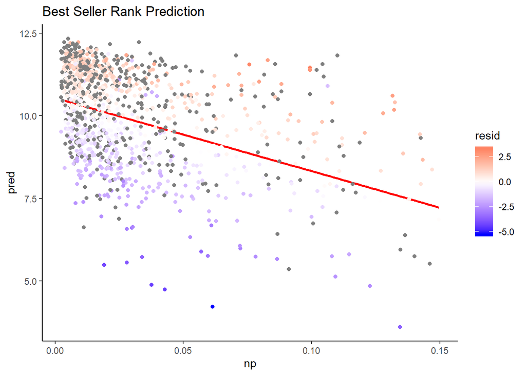

## Summary and Wayforward

1. **Games category** has the largest number of reviews with fair amount of products, and this category produced several top popularity products. If a new product from this category appeared in the market, it is highly likely to be popular.
2. **Big brands** is another good indicator of popular products. The famous brand names, such as LEGO, have great influence towards customers. Products from those big manufacturers have many varieties and high sales volume.
3. **Amazon Best Seller Rank** shows the popularity of the product. The faster the product sold, the higher the seller rank becomes. It is a good esitmator for future sales and could improve sales since Amazon has certain promotion activities towards the high rank products.
4. In the predictive model for Best Seller Rank, I used number of reviews data to represent the sales volume. If used the sales data, the model would be more accurate. Besides, Amazon Best Seller Rank updates hourly and reflects both current sales and historical data. It would be better if could use time serious model to predict the BSR.
5. Could do more sentimental analysis on the customer reviews to see why those products are popular and thus give suggestions to the manufacturers and sellers.

## Appendix A. Metadata

Product:

| Variables | Description |
| --- | --- |
| uniq_id | [Char] Unique product id |
| product_name | [Char] Product name |
| manufacturer | [Char] The item manufacturer, as reported on Amazon. Some common “manufacturers”, like Disney, actually outsource their assembly line. |
| price | [Num] Product price (£) |
| number_in_stock | [Num] Number available in stock |
| stock_type | [Char] Stock type |
| number_of_reviews | [Num] Number of customer reviews |
| number_of_answered_questions | [Num] Amazon includes a Question and Answer service on all or most of its products. This field is a count of how many questions that were asked actually got answered. |
| average_review_rating | [Num] Product average review rating, scale 0 - 5 |
| also_bought_count | [Num] Count of other items that similar users bought |
| buy_after_viewing_this_count | [Num] Count of other items that customers bought after viewing this product |
| seller_count | [Num] Count of sellers for the product |
| product_information | [Char] Detailed product information |
| product_description | [Char] Product description |

Category:

| Variables | Description |
| --- | --- |
| uniq_id | [Char] Unique product id |
| product_name | [Char] Product name |
| amazon_category, subcat1, subcat2, subcat3, subcat4 | [Char] A tree-based, “>”-delimited categorization for the item in question. Amazon_category is the root level, and subsets are leaf levels |

Also_Bought:

| Variables | Description |
| --- | --- |
| uniq_id | [Char] Unique product id |
| product_name | [Char] Product name |
| also_bought_count | [Num] Count of other items that similar users bought |
| buy_after_viewing_this_count | [Num] Count of other items that customers bought after viewing this product |
| also_bought_1, also_bought_2, …, also_bought_12 | [Char] References (urls) to other items that similar users bought. This is a recommendation engine component that played a big role in making Amazon popular initially. |
| buy_after_view_1, buy_after_view_2, buy_after_view_3, buy_after_view_4 | [Char] Other items that customers bought after viewing this product (urls) |

QandA:

| Variables | Description |
| --- | --- |
| uniq_id | [Char] Unique product id |
| product_name | [Char] Product name |
| q1,a1 q2,a2 … q10,a10 | [Char] Product’s question and answer pairs. q1-q10 are customer questions, and a1-a10 are corresponding answers. |

Reviews:

| Variables | Description |
| --- | --- |
| uniq_id | [Char] Unique product id |
| product_name | [Char] Product name |
| r.user.1, r.user.2, … , r.user.8 | [Char] Username of the consumers |
| r.title.1, r.title.2, … , r.title.8 | [Char] Review title from the consumers |
| r.text.1, r.text.2, … , r.text.8 | [Char] Review text from the consumers |
| r.rating.1, r.rating.2, … , r.rating.8 | [Num] Rating from the consumers |
| r.date.1, r.date.2, … , r.date.8 | [Date] Review date posted |

Sellers:

| Variables | Description |
| --- | --- |
| uniq_id | [Char] Unique product id |
| product_name | [Char] Product name |
| seller_count | [Num] Count of sellers for the product |
| seller_name_1, seller_name_2, … , seller_name_20 | [Char] Seller names |
| seller_price_1, seller_price_2, … , seller_price_20 | [Num] Price from each seller |

## Appendix B. Sample Codes

1. Used **tidyr, stringr, lubridate** to clean the data

   ```yaml
   ---
   # Data wrangling with subset(), separate(), mutate(), pipe function and regular expression
   Reviews[,seq(from = 5, to = 40, by = 5)] <- lapply(Reviews[,seq(from = 5, to = 33, by = 5)], dmy)
   Product <- subset(Toys_Amazon_cd,
           select = c(uniq_id, ..., number_available_in_stock, product_information)) %>%
           separate(number_available_in_stock, c("number_in_stock", "stock_type"))
   Product$number_in_stock <- as.numeric(Product$number_in_stock)
   Product <- Product %>%
     mutate(best_seller_rank = str_extract(Product$product_information, "Best Sellers Rank \\d+\\,\\d+,\\d+ |Best Sellers Rank \\d+\\,\\d+ |Best Sellers Rank \\d+ "))
   Product$best_seller_rank <- Product$best_seller_rank %>% str_remove_all("Best Sellers Rank |\\,") %>% as.numeric()
   ---
   ```

2. Used **tidyverse, dplyr** for data wrangling

   ```yaml
   ---
   # Data cleaning with summarize(), filter(), arrange(), etc
   Category2 <- cbind(Category, Toys_Amazon_cd$number_of_reviews, Toys_Amazon_cd$average_review_rating) %>%
     group_by(amazon_category)
   category_summarize <- summarise(Category2,
                               cat_avgrating = round((mean(average_review_rating, na.rm = TRUE)),digits = 2))
   category_summarize %>% filter(cat_count >= 100) %>% arrange(-cat_count)
   ---
   ```

3. Used **ggplot2** to visualize the data

   ```yaml
   ---
   # Create the bar plot with ggplot()
   ggplot(df1, aes(x="", y = n, fill=manufacturer)) +
   geom_bar(width = 0.6, stat = "identity") +
   labs(x="", y="", title="Top Products Manufacturers") + theme_void()
   ---
   ```

4. Used **modelr** to create statistical models

   ```yaml
   ---
   # Build the BSR model with lm()
   BSR <- lm(lb ~ np +  seller_count + price, data = P3)
   summary(BSR)
   par(mfrow = c(2, 2))
   plot(BSR)
   ---
   ```

## Appendix C. Reflection and Improvements

After hours of work on this Toys on Amazon dataset, I learned a lot about data analyzing and data story-telling. During several assignments, the reports reflected multiple changes versus the very first version. For example, the final report format changed from simple default rmarkdown to handout version, the whole storyline changed from the first time simple exploration to a updated version including predictive modeling, simple default graphics to customized plots, better data formatting, etc. The most obvious change is the code. With more knowledge and experience on writing R codes, now my codes could better help my analysis and easy to read. Below shows one piece of code improvement:

```yaml
---
# Previous version
Toys_Amazon_cd2 <- group_by(Toys_Amazon_cd, amazon_category)
Toys_Amazon_cd2$count <- ifelse(is.na(Toys_Amazon_cd2$amazon_category), 0, 1)
category_summarize <- summarise(Toys_Amazon_cd2, cat_avgrating = round((mean(average_review_rating, na.rm = TRUE)),digits = 2),
                                cat_avgprice = round((mean(price, na.rm = TRUE)),digits = 2),
                                cat_maxprice = max(price, na.rm = TRUE),
                                cat_minprice = min(price, na.rm = TRUE),
                                cat_count = sum(count))
category_summarize <- arrange(category_summarize, -cat_count)
category_summarize %>%
  filter(cat_count >= 100) %>%
  ggplot(aes(x=reorder(amazon_category, cat_count), y=cat_count)) +
  geom_bar(stat = "identity") +
  geom_text(aes(label = cat_count), hjust=1.2, color = "white") +
  labs(x="Amazon Category", y="Category Product Amount", title="Category Product Amount") +
  coord_flip()

# Updated version: updated the data table with only useful variables, using pipe function to simplify the codes, and better graphic shown
Category2 <- cbind(Category, Toys_Amazon_cd$number_of_reviews, Toys_Amazon_cd$average_review_rating) %>%
  group_by(amazon_category) %>%
  mutate(count = ifelse(is.na(amazon_category), 0, 1))
names(Category2)[8] <- "number_of_reviews"
names(Category2)[9] <- "average_review_rating"
category_summarize <- summarise(Category2,
                                cat_avgrating = round((mean(average_review_rating, na.rm = TRUE)),digits = 2),
                                cat_reviews = sum(number_of_reviews, na.rm = TRUE),
                                cat_count = sum(count))

category_summarize %>%
  filter(cat_count >= 100) %>%
  arrange(-cat_count) %>%
  ggplot(aes(x=reorder(amazon_category, cat_count), y=cat_count)) +
  geom_point() +
  labs(x="Amazon Category", y = "", title="Category Product Amount") +
  coord_flip() + theme_classic()

---
```